# Chapter 2 - Graphs

In this section we introduce basic Python commands needed to illustrate data graphically.

```python
# This imports the necessary Python modules needed to do basics statistics

import numpy as np
import matplotlib.pyplot as plt
import pandas as pd
```

# Frequency Table

A frequency table organizes data by illustrating how many of observations occur of each possible result of an experiment. The number of observations of a particular result is known as the **freqeuency** of the result.

```python
# Generate 50 random integers from 0 to 9

data = np.random.randint(10, size=50)
data
```

```
array([2, 7, 8, 2, 7, 2, 4, 0, 0, 1, 0, 2, 0, 5, 9, 0, 9, 5, 3, 2, 9, 9,
       5, 8, 7, 8, 6, 1, 2, 4, 8, 0, 8, 5, 1, 7, 0, 6, 7, 8, 3, 5, 5, 0,
       7, 1, 1, 3, 1, 5])
```

```python
# Organizing the data into a pandas Series object for easy processing

data = pd.Series(data)
data.value_counts().sort_index()
```

```
0    8
1    6
2    6
3    3
4    2
5    7
6    2
7    6
8    6
9    4
Name: count, dtype: int64
```

# Line Graph

A line graph is a visual representation of a frequency table. It is a plot of points where the $x$-values are the posible results of an experiment and the $y$-values are the frequencies of each particular result.

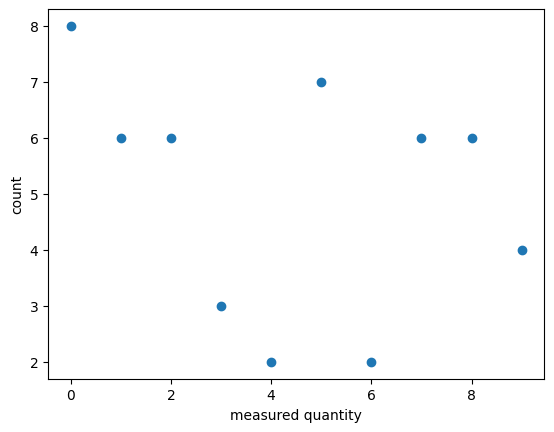

```python
sorted_data = data.value_counts().sort_index()
plt.scatter(sorted_data.index, sorted_data)
plt.xlabel('measured quantity')
plt.ylabel('count')
plt.show()
```

# Bar Graph

A bar graph is similar to a line graph using bars rather than individual points.

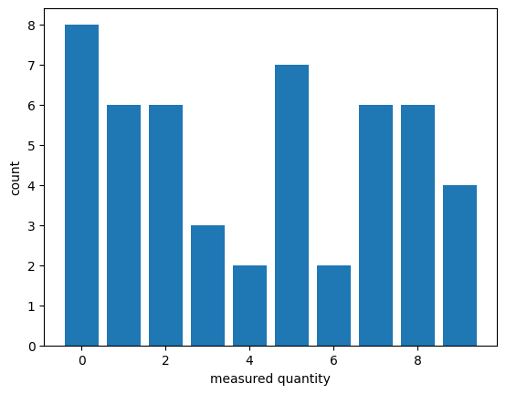

```python
plt.bar(sorted_data.index, sorted_data)
plt.xlabel('measured quantity')
plt.ylabel('count')
plt.show()
```

# Frequency Polygon

A frequency polygon is like a line graph where the points are connected via straight lines.

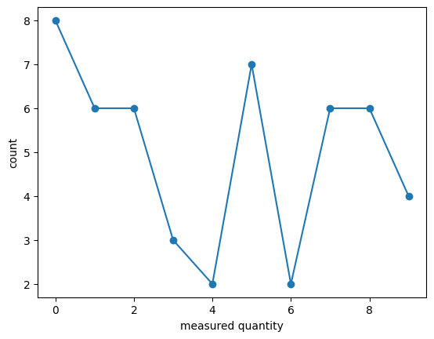

```python
plt.plot(sorted_data.index, sorted_data, marker='o')
plt.xlabel('measured quantity')
plt.ylabel('count')
plt.show()
```

# Symmetric vs. Non-Symmetric Data

A data set is **symmetric** about a value $x_0$ if the frequency of the values $x_0-c$ and $x_0+c$ are the same for all $c$. If no such $x_0$ exists, the data set is **non-symmetric**.

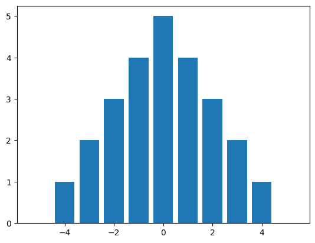

```python
# Symmetric dataset

x = np.arange(-5,6)
symmetric_data = 5 - np.abs(x)
plt.bar(x, symmetric_data)
plt.show()
```

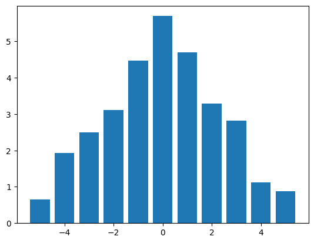

```python
# Non-symmetric data set

x = np.arange(-5,6)
symmetric_data = 5 - np.abs(x) + np.random.rand(11)
plt.bar(x, symmetric_data)
plt.show()
```

# Relative Frequency

If the frequency of a particular result is $f$ and the total number of observations is $n$, then the **relative frequency** of the result is $f/n$.

```python
# Relative frequency of values above

sorted_data_freq = sorted_data/len(data)
sorted_data_freq
```

```
0    0.16
1    0.12
2    0.12
3    0.06
4    0.04
5    0.14
6    0.04
7    0.12
8    0.12
9    0.08
Name: count, dtype: float64
```

# Pie Charts

A part chart is a graph that illustrates relative frequencies for observations whose results are not numerical.

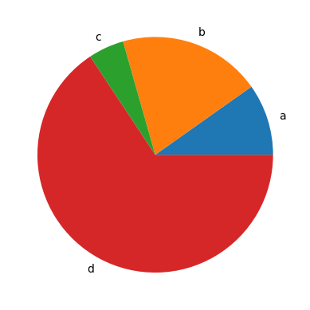

```python
values = [10,20,5,67]
my_labels = ['a','b','c','d']
plt.pie(values,labels=my_labels)
plt.show()
```

# Histograms

In some cases, a frequency table or bar graph is impractical if the number of possible outcomes of a experiment is large. In this case, we can establish groups or **class intervals** where we plot the frequency of the groups rather than individual values.

```python
# Data set of 301 possible different results

data2 = np.random.randint(301,size=100)
```

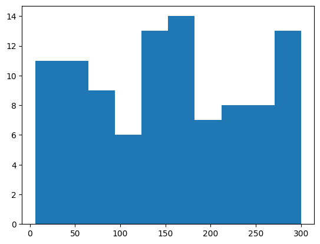

```python
# This histogram breaks the data set into 10 different class intervals
# that are equally spaced

plt.hist(data2,bins=10)
```

# Stem-and-Leaf Plot

A stem-and-leaf plot divides the data into to parts, the stem and leaf.

This can best be understood via the following example. Suppose that some data set has the values $$3,26,31,18,18,17,23,9,44.$$ Then we split the data so that the stems are the tens place and the leaves are the ones place.

| Stem | Leaf |
| --- | --- |
| 0 | 3,9 |
| 1 | 7,8,8 |
| 2 | 3,6 |
| 3 | 1 |
| 4 | 4 |